# Visualisation and comparison of ChIP peaks between different datasets

Cosette Schupfer

04/08/2020

#Load packages

#assgn database used for annotation (mm10 is used here specifically for the genome for mus musculus)

```r
txdb <- TxDb.Mmusculus.UCSC.mm10.knownGene
```

#load datafiles (input: bed files from MACS output)

```r
#Get files
files <-getSampleFiles()
print(files)
```

```
## $BFoxg1_MNS.bed
## [1] "C:/Users/user/OneDrive/Documents/R/win-library/4.0/ChIPseeker/extdata/GEO_sample_data/BFoxg1_MNS.bed"
##
## $CFoxg1_E15.5C.bed
## [1] "C:/Users/user/OneDrive/Documents/R/win-library/4.0/ChIPseeker/extdata/GEO_sample_data/CFoxg1_E15.5C.bed"
##
## $GFoxg1_E14.5C1.tsv
## [1] "C:/Users/user/OneDrive/Documents/R/win-library/4.0/ChIPseeker/extdata/GEO_sample_data/GFoxg1_E14.5C1.tsv"
##
## $GFoxg1_E14.5C2.tsv
## [1] "C:/Users/user/OneDrive/Documents/R/win-library/4.0/ChIPseeker/extdata/GEO_sample_data/GFoxg1_E14.5C2.tsv"
##
## $SPax6_E12.5F.gz
## [1] "C:/Users/user/OneDrive/Documents/R/win-library/4.0/ChIPseeker/extdata/GEO_sample_data/SPax6_E12.5F.gz"
```

```r
peak <- readPeakFile(files[[5]])
```

#Convert to genomic ranges GRanges is a package optimised for storing storing and manipulating genomic intervals along a genome. The code below also allows naming of datasets.

```r
peak1 = GenomicRanges::GRangesList(GFoxg1_E14.5C1=readPeakFile(files[[3]]),
                                GFoxg1_E14.5C2=readPeakFile(files[[4]]),
                                BFoxg1_MNS=readPeakFile(files[[1]]),
                                CFoxg1_E15.5C=readPeakFile(files[[2]]),
                                SPax6_E12.5F=readPeakFile(files[[5]]))
```

#Heatmap of distribution of peaks relative to TSS. Commonly, annotation of ChIP-peaks to likely regulatory genes is based on the assumption that transcription factor regulation occurs through binding to a cis-regulatory sequence close to the transcription start site of a gene. It is important to note that gene regulation often follows a more complex regulatory landscape. Here, we define the TSS region as 3000 pb upstream and downstream of the TSS of a gene. The heatmap gives a global evaluation of the density of peaks within the TSS region. Different colours were assigned to distinguish between datasets.

```
## >> preparing promoter regions...  2020-08-04 14:24:18
```

[output not shown]

```
## >> preparing tag matrix...        2020-08-04 14:24:20
## >> generating figure...       2020-08-04 14:25:19
```

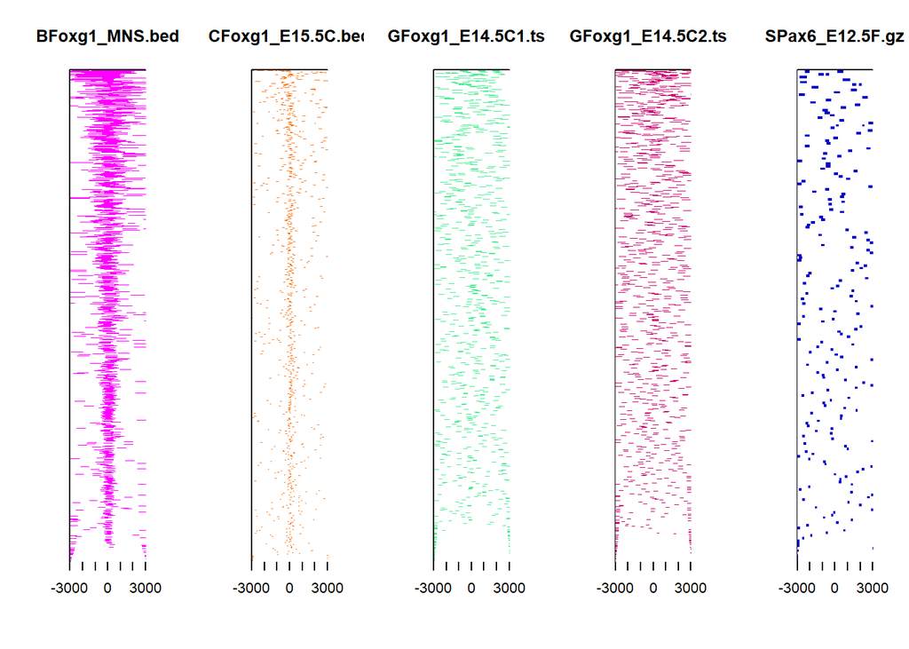

```
## >> done...            2020-08-04 14:25:29
```

```r
peakHeatmap(files[1:5], TxDb=txdb, upstream=3000, downstream=3000, color = c("magenta", "chocolate1", "seagreen2", "deeppink3", "mediumblue"))
```

#Average profile of ChIP peaks within TSS region Similar to the heatmap visualisation, this allows comparison of the density of peaks near the TSS between datasets.

```
## >> preparing promoter regions...  2020-08-04 14:25:33
## >> preparing tag matrix...        2020-08-04 14:25:33
## >> plotting figure...             2020-08-04 14:26:16
```

[output not shown]

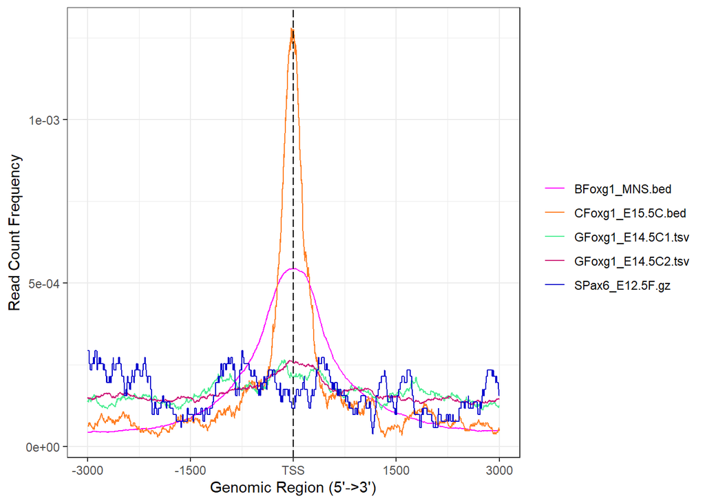

```r
plotAvgProf2(files[1:5], TxDb=txdb, upstream=3000, downstream=3000,
             xlab="Genomic Region (5'->3')", ylab = "Read Count Frequency") +
             scale_colour_manual(values = c("magenta", "chocolate1", "seagreen2", "deeppink3", "mediumblue"))
```

#Include confidence intervals Optionally, you may include confidence intervals calculcated through the bootstrapping method

```
## >> preparing promoter regions...  2020-08-04 14:26:17
## >> preparing tag matrix...        2020-08-04 14:26:17
## >> plotting figure...             2020-08-04 14:26:58
## >> Running bootstrapping for tag matrix...        2020-08-04 14:27:57
## >> Running bootstrapping for tag matrix...        2020-08-04 14:28:32
## >> Running bootstrapping for tag matrix...        2020-08-04 14:28:54
## >> Running bootstrapping for tag matrix...        2020-08-04 14:29:52
## >> Running bootstrapping for tag matrix...        2020-08-04 14:29:59
```

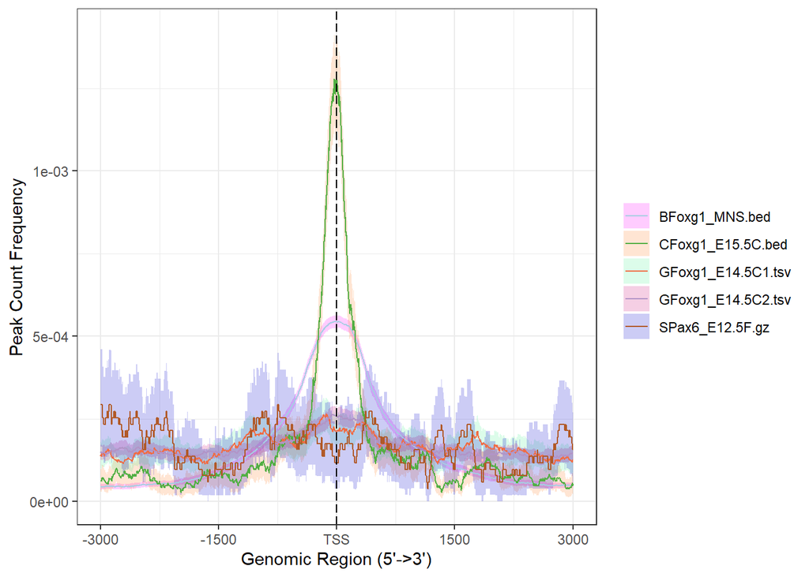

```r
plotAvgProf2(files[1:5], TxDb=txdb, upstream=3000, downstream=3000, conf = 0.95, resample = 1000)+
  scale_fill_manual(values = c("magenta", "chocolate1", "seagreen2", "deeppink3", "mediumblue"))
```